# Project Python Foundations: FoodHub Data Analysis Study

## 23rd September, 2022.

## Contents / Agenda

Executive Summary

Business Problem Overview and Solution Approach

Data Overview

EDA - Univariate Analysis

EDA - Multivariate Analysis

Appendix

## Executive Summary

The Mission

Foodhub provides and delivers healthy, fresh, delicious and good quality cuisines timely.

Overview

Foodhub began as a delivery service. It was founded by David McKellan and Angel Cruz after they completed their college education. Foodhub started operations from the garage of Angel's house.

Our Target Market

Foodhub hopes to serve busy professionals, students and people of all works of life in and around Newyork.

Opportunities for Investment

Currently,Foodhub is looking for investment partners from Food entreprenuers Foodhub based on the technology provided to restaurants generated a total revenue of 6166.3 dollars.

Achievements Foodhub has 178 partner restaurants . A total of 1898 orders where placed by 1200 customers. The highest orders (13 orders) was placed by a customer with Customer ID 52832. Shake Shack restaurant received a total of 219 orders and a revenue of 3579.53 dollars which is the highest in the dataset. American cuisine which was 584 orders had the highest orders placed while Vietnamese cuisine with only 7 orders was the least.

## Business Problem Overview and Solution Approach

Problem

Junk foods has immersely made people unhealthy. According to USA Today, 68.6% of the population are obessed, while 40% of adults battle with ailments related to bad nutrition.

The Solution

Foodhub provides 14 differnt types of cusines from 178 restaurants who prepare world class delicacies with lots of health benefits.

## Business Context

The number of restaurants in New York is increasing daily. Lots of students and busy professionals rely on these restaurants due to their hectic lifestyles. Online food delivery service is a great option for them. It provides them with good food from their favorite restaurants. A food aggregator company FoodHub offers access to multiple restaurants through a single smartphone app.

The app allows the restaurants to receive a direct online order from a customer. The app assigns a delivery person from the company to pick up the order after it is confirmed by the restaurant. The delivery person then uses the map to reach the restaurant and waits for the food package. Once the food package is handed over to the delivery person, he/she confirms the pick-up in the app and travels to the customer's location to deliver the food. The delivery person confirms the drop-off in the app after delivering the food package to the customer. The customer can rate the order in the app. The food aggregator earns money by collecting a fixed margin of the delivery order from the restaurants.

### Objective

Perform data analysis on dataset provided from the database and help company make informed decisions to improve business processes.

### Data Description

The data contains the different data related to a food order. The detailed data dictionary is given below.

### Data Dictionary

order_id: Unique ID of the order

customer_id: ID of the customer who ordered the food

restaurant_name: Name of the restaurant

cuisine_type: Cuisine ordered by the customer

cost: Cost of the order

day_of_the_week: Indicates whether the order is placed on a weekday or weekend (The weekday is from Monday to Friday and the weekend is Saturday and Sunday)

rating: Rating given by the customer out of 5

food_preparation_time: Time (in minutes) taken by the restaurant to prepare the food. This is calculated by taking the difference between the timestamps of the restaurant's order confirmation and the delivery person's pick-up confirmation.

delivery_time: Time (in minutes) taken by the delivery person to deliver the food package. This is calculated by taking the difference between the timestamps of the delivery person's pick-up confirmation and drop-off information

## Data Overview

The initial steps to understand any dataset is to:

1. Observe the first few rows of the dataset, to check whether the dataset has been loaded properly or not
2. Get information about the number of rows and columns in the dataset
3. Find out the data types of the columns to ensure that data is stored in the preferred format and the value of each property is as expected.
4. Check the statistical summary of the dataset to get an overview of the numerical columns of the data

## Importing the libraries

```python
# import libraries for data manipulation
import numpy as np
import pandas as pd

# import libraries for data visualization
import matplotlib.pyplot as plt
import seaborn as sns
```

## Understanding the structure of the data

```python
# uncomment and run the following lines for Google Colab
# from google.colab import drive
# drive.mount('/content/drive')
```

```python
# import libraries for data manipulation
import numpy as np
import pandas as pd

# import libraries for data visualization
import matplotlib.pyplot as plt
import seaborn as sns
df = pd.read_csv("foodhub_order (2).csv")
# returns the first 5 rows
df.head()
```

|  | order_id | customer_id | restaurant_name | cuisine_type | cost_of_the_order | day_of_the_week | rating | food_preparation_time | delivery_time |
| --- | --- | --- | --- | --- | --- | --- | --- | --- | --- |
| 0 | 1477147 | 337525 | Hangawi | Korean | 30.75 | Weekend | Not given | 25 | 20 |
| 1 | 1477685 | 358141 | Blue Ribbon Sushi Izakaya | Japanese | 12.08 | Weekend | Not given | 25 | 23 |
| 2 | 1477070 | 66393 | Cafe Habana | Mexican | 12.23 | Weekday | 5 | 23 | 28 |
| 3 | 1477334 | 106968 | Blue Ribbon Fried Chicken | American | 29.20 | Weekend | 3 | 25 | 15 |
| 4 | 1478249 | 76942 | Dirty Bird to Go | American | 11.59 | Weekday | 4 | 25 | 24 |

### Observations :

The DataFrame has 9 columns as mentioned in the Data Dictionary. Data in each row corresponds to the order placed by a customer.

## Question 1: How many rows and columns are present in the data?

```python
# Check the shape of the dataset
df.shape
```

```
(1898, 9)
```

### Observations :

The dataset has 1898 rows and 9 columns

## Question 2: What are the datatypes of the different columns in the dataset?

```python
df.info()
```

```
<class 'pandas.core.frame.DataFrame'>
RangeIndex: 1898 entries, 0 to 1897
Data columns (total 9 columns):
 #   Column                 Non-Null Count  Dtype
---  ------                 --------------  -----
 0   order_id               1898 non-null   int64
 1   customer_id            1898 non-null   int64
 2   restaurant_name        1898 non-null   object
 3   cuisine_type           1898 non-null   object
 4   cost_of_the_order      1898 non-null   float64
 5   day_of_the_week        1898 non-null   object
 6   rating                 1898 non-null   object
 7   food_preparation_time  1898 non-null   int64
 8   delivery_time          1898 non-null   int64
dtypes: float64(1), int64(4), object(4)
memory usage: 133.6+ KB
```

### Observations :

RangeIndex: 1898 entries, 0 to 1897

Data columns: 9 columns

dtypes: float64(1), int64(4), object(4):

memory usage: 133.6+ KB

## Question 3: Are there any missing values in the data? If yes, treat them using an appropriate method.

```python
# Checking for the missing data
df.isnull().sum()
```

```
order_id                 0
customer_id              0
restaurant_name          0
cuisine_type             0
cost_of_the_order        0
day_of_the_week          0
rating                   0
food_preparation_time    0
delivery_time            0
dtype: int64
```

### Observations :

Missing values occur when no data value is stored for the variable in an observation. There are no mising values in the data.

## Question 4: Check the statistical summary of the data. What is the minimum, average, and maximum time it takes for food to be prepared once an order is placed?

```python
# To get the minimum food preparation time
df['food_preparation_time'].min()
```

```
20
```

```python
# To get the average food preparation time
df['food_preparation_time'].mean()
```

```
27.371970495258168
```

```python
# To get the maximium food preparation time
df['food_preparation_time'].max()
```

```
35
```

### Observations :

The minimum food preparation time is 20 minutes

The average food preparation time is 27.371970495258168 minutes

The maximum food preparation time is 35 minutes

## Question 5: How many orders are not rated?

```python
# Orders that are not rated
df['rating'].value_counts()
```

```
Not given    736
5            588
4            386
3            188
Name: rating, dtype: int64
```

### Observations :

736 orders in the dataset were not rated.

## Exploratory Data Analysis (EDA)

## Question 6: Explore all the variables and provide observations on their distributions. (Generally, histograms, boxplots, countplots, etc. are used for univariate exploration.)

### Let's check for numerical columns

### Order ID

```python
# check unique order ID
df['order_id'].nunique()
```

```
1898
```

### Observations :

The total number of orders placed were 1898.

### Customer ID

```python
# check unique customr ID
df['customer_id'].nunique()
```

```
1200
```

### Observations :

A total of 1200 customers placed orders in the restaurants.

### Restaurant name

```python
# check unique restaurant name
df['restaurant_name'].nunique()
```

```
178
```

### Observations:

A total number of 178 restaurants are in the dataset.

### Cusine name

```python
# Check unique cuisine name
df['cuisine_type'].nunique()
```

```
14
```

### Observations :

There are 14 different cuisine names in the dataset.

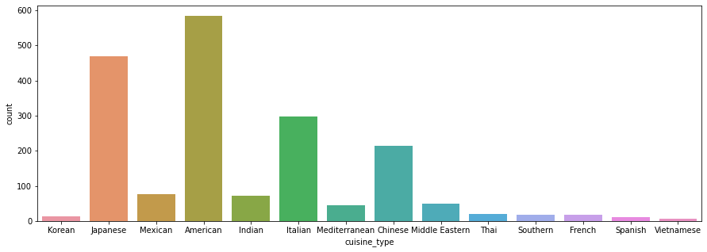

```python
plt.figure(figsize = (15,5))
sns.countplot(data = df, x = 'cuisine_type')
```

### Observation :

American 584, Japanese 470, Italian 298, Chinese 215, Mexican 77, Indian 73, Middle Eastern 49, Mediterranean 46, Thai 19, French 18, Southern 17, Korean 13, Spanish 12, Vietnamese 7.

The American Cusine has the highest order while the Vietnamese Cusine has the least order.

### Day of the week

```python
# To check unique days of the week
df['day_of_the_week'].nunique()
```

```
2
```

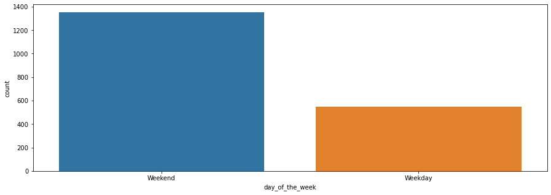

```python
plt.figure(figsize = (15,5))
sns.countplot(data = df, x = 'day_of_the_week')
```

### Observation :

The days of the week was categorized into 2 (weekend and weekday) in the dataset. Most orders were placed on weekends.

### Rating

```python
# Check unique values for rating
df['rating'].nunique()
```

```
4
```

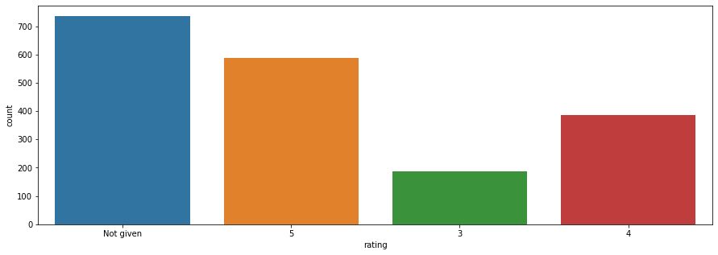

```python
plt.figure(figsize = (15,5))
sns.countplot(data = df, x = 'rating')
```

### Observations:

Not given == 736, 5 == 588, 4 == 386, 3 == 188.

### Food Preparation Time

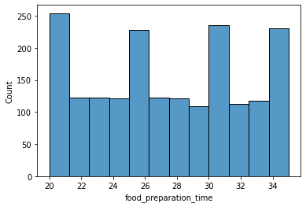

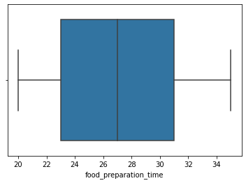

```python
# Check food preparation time using histogram and boxplot
sns.histplot(data=df,x="food_preparation_time")
plt.show()
sns.boxplot(data=df,x='food_preparation_time')
plt.show()
```

### Observation :

Most of the cusines where prepared in 21 minutes,

35 minutes is the maximum time used to prepare a cuisine.

### Delivery time

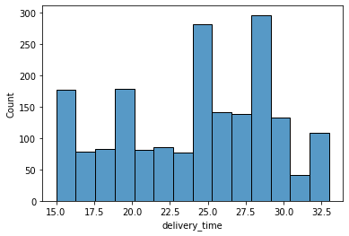

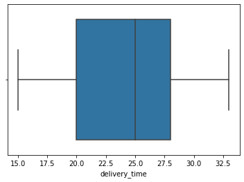

```python
# To check the delivery time
sns.histplot(data = df, x = 'delivery_time')
plt.show()
sns.boxplot(data = df, x = 'delivery_time')
plt.show()
```

### Observation :

The histogram plot show a non symetrical bimodal distribution. The boxplot shows the Median delivery time is 25 minutes and there are no outliers.

## Question 7: Which are the top 5 restaurants in terms of the number of orders received?

```python
# To check the top 5 restaurants by thhe number of orders
df['restaurant_name'].value_counts().head(5)
```

```
Shake Shack                  219
The Meatball Shop            132
Blue Ribbon Sushi            119
Blue Ribbon Fried Chicken     96
Parm                          68
Name: restaurant_name, dtype: int64
```

### Observations :

The top 5 restaurants in terms of orders received are

Shake Shack == 219,

The Meatball Shop == 132,

Blue Ribbon Sushi == 119,

Blue Ribbon Fried Chicken == 96,

Parm == 68

## Question 8: Which is the most popular cuisine on weekends?

```python
# The most popular cuisine on weekends
df_weekend = df[df['day_of_the_week'] == 'Weekend']
df_weekend['cuisine_type'].value_counts().head(5)
```

```
American    415
Japanese    335
Italian     207
Chinese     163
Mexican      53
Name: cuisine_type, dtype: int64
```

### Observations :

The most popular cusine ordered on weekends is the American cuisine with 415 orders.

## Question 9: What percentage of the orders cost more than 20 dollars?

```python
# Orders that cost more than 20 dollars
df_greater_than_20 = df[df['cost_of_the_order'] > 20]

# Calculate the number of total orders where the cost is greater than 20 dollars
print('The number of total orders that cost above 20 dollars is:', df_greater_than_20.shape[0])

# Calculate percentage of such orders in the dataset
percentage = (df_greater_than_20.shape[0] / df.shape[0]) * 100

print("Percentage of orders above 20 dollars:", round(percentage, 2), '%')
```

```
The number of total orders that cost above 20 dollars is: 555
Percentage of orders above 20 dollars: 29.24 %
```

### Obsservations :

A total of 555 orders cost more than 20 dollars and it's percentage is 29.24%

## Question 10: What is the mean order delivery time?

```python
# The mean order delivery time
df['delivery_time'].mean()
```

```
24.161749209694417
```

### Observations :

The mean(average) time used to deliver cuisine to customers is 24.161749209694417 minutes.

```python
### Observations :
```

## Question 11: The company has decided to give 20% discount vouchers to the top 3 most frequent customers. Find the IDs of these customers and the number of orders they placed.

```python
# The counts of  each customer_id
df['customer_id'].value_counts().head(3)
```

```
52832    13
47440    10
83287     9
Name: customer_id, dtype: int64
```

### Observations :

The top 3 most frequent customers id are:

52832 with 13 orders,

47440 with 10 orders,

83287 with 9 orders.

## Question 12: Perform a multivariate analysis to explore relationships between the important variables in the dataset. (It is a good idea to explore relations between numerical variables as well as relations between numerical and categorical variables)

### Cuisine vs Cost of the order

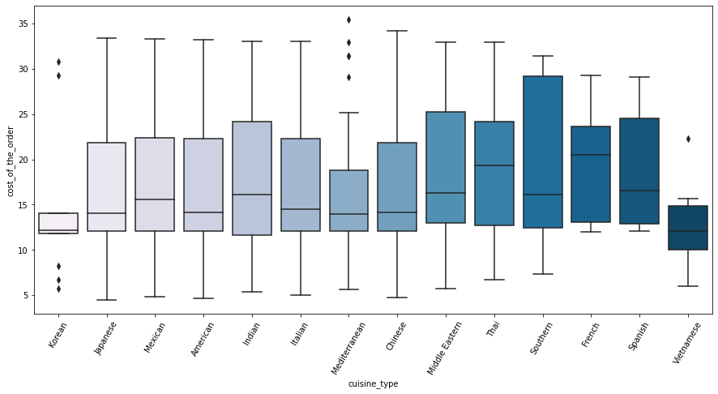

```python
# Relationship between cost of the order and cuisine type
plt.figure(figsize=(15,7))
sns.boxplot(x = "cuisine_type", y = "cost_of_the_order", data = df, palette = 'PuBu')
plt.xticks(rotation = 60)
plt.show()
```

### Observations :

Korean, Mediterranean and Vietnamese cuisines have outliers. The other cuisines have all values within the 4 quartiles.

### Cuisine vs Food Preparation time

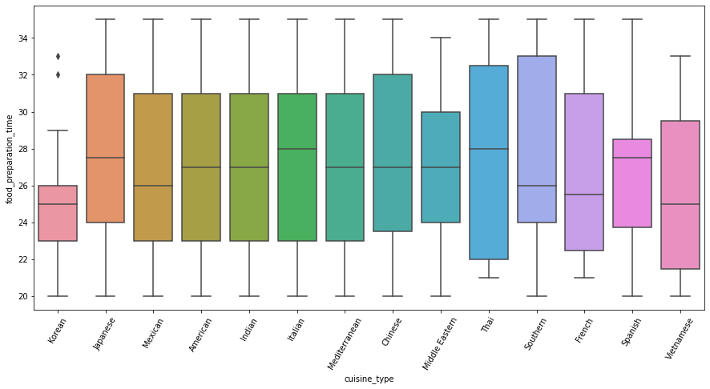

```python
# Relationship between food preparation time and cuisine type
plt.figure(figsize=(15,7))
sns.boxplot(x = 'cuisine_type', y = 'food_preparation_time', data = df)
plt.xticks(rotation = 60)
plt.show()
```

### Obseservations :

Only the Korean cuisine has outliers. The other cuisines all have values within the quartiles.

### Day of the Week vs Delivery time

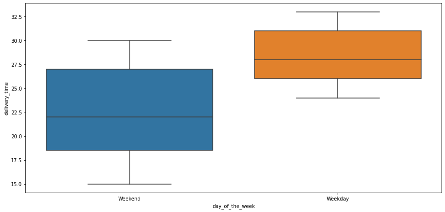

```python
# Relationship between day of the week and delivery time
plt.figure(figsize=(15,7))
sns.boxplot(x = 'day_of_the_week', y = "delivery_time", data = df)
plt.show()
```

### Observations :

Delivery time of cuisines is faster on weekend than weekdays, this could be due to high vehicular movements on weekdays.

### Revenue generated by the restaurants

```python
df.groupby(['restaurant_name'])['cost_of_the_order'].sum().sort_values(ascending = False).head(14)
```

```
restaurant_name
Shake Shack                      3579.53
The Meatball Shop                2145.21
Blue Ribbon Sushi                1903.95
Blue Ribbon Fried Chicken        1662.29
Parm                             1112.76
RedFarm Broadway                  965.13
RedFarm Hudson                    921.21
TAO                               834.50
Han Dynasty                       755.29
Blue Ribbon Sushi Bar & Grill     666.62
Rubirosa                          660.45
Sushi of Gari 46                  640.87
Nobu Next Door                    623.67
Five Guys Burgers and Fries       506.47
Name: cost_of_the_order, dtype: float64
```

### Observations :

Shake Shack generated the highest revenue which is $3579.53.

### Rating vs Delivery time

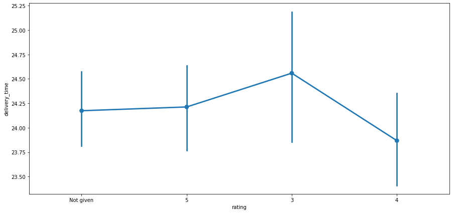

```python
# Relationship between rating and delivery time
plt.figure(figsize=(15, 7))
sns.pointplot(x = 'rating', y = 'delivery_time', data = df)
plt.show()
```

### Observations:

The rating conmpared to delivery time slightly increased between 'Not given' and '5', it then jumps to 3 and declines to 4.

### Rating vs Food preparation time

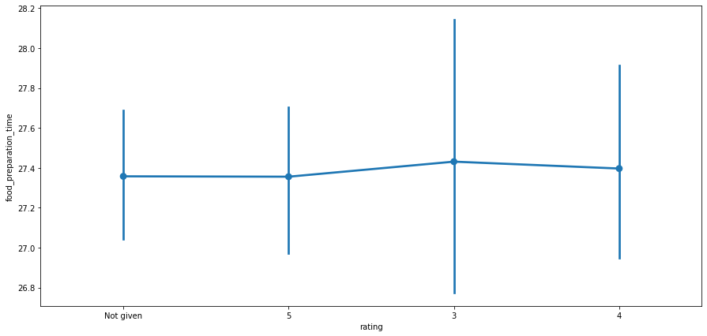

```python
# Relationship between rating and food preparation time
plt.figure(figsize=(15, 7))
sns.pointplot(x = "rating", y = "food_preparation_time", data = df)
plt.show()
```

### Obsevations :

The food preparation time from "Not given" to 5 is linear, a slight increase to 3 from 5 and a slight decrease to 4.

### Rating vs Cost of the order

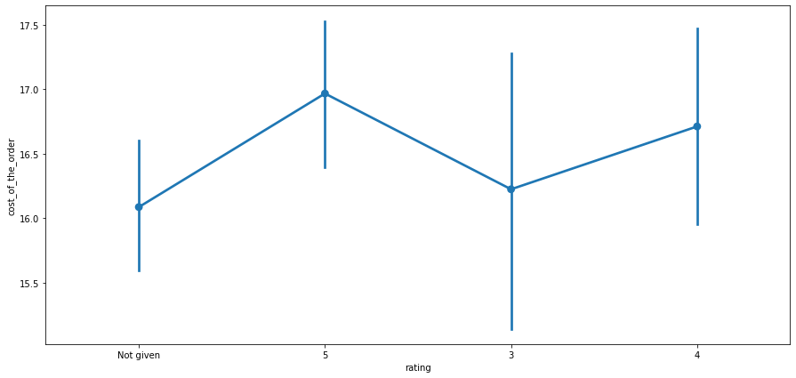

```python
# Relationship between rating and cost of the order
plt.figure(figsize=(15, 7))
sns.pointplot(x ='rating', y = 'cost_of_the_order', data = df)
plt.show()
```

### Observations :

The rating 'Not given' jumps from around 16 dollars to rating of 5 around 17 dollars It declines to rating 3 and jumps again to rating 4.

### Correlation among variables

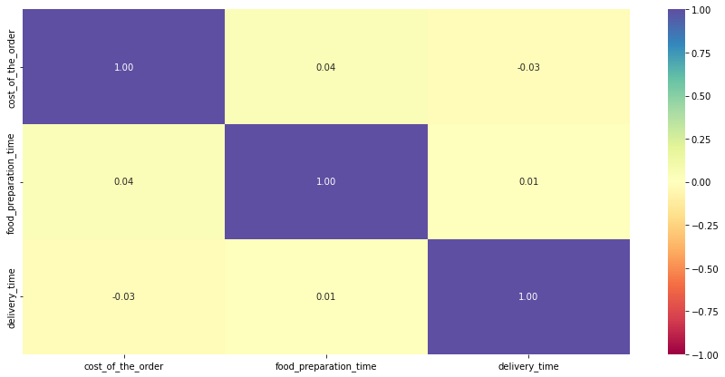

```python
# Plot the heatmap
col_list = ['cost_of_the_order', 'food_preparation_time', 'delivery_time']
plt.figure(figsize=(15, 7))
sns.heatmap(df[col_list].corr(), annot=True, vmin=-1, vmax=1, fmt=".2f", cmap="Spectral")
plt.show()
```

### Question 13: The company wants to provide a promotional offer in the advertisement of the restaurants. The condition to get the offer is that the restaurants must have a rating count of more than 50 and the average rating should be greater than 4. Find the restaurants fulfilling the criteria to get the promotional offer.

```python
# Filter the rated restaurants
df_rated = df[df['rating'] != 'Not given'].copy()

# Convert rating column from object to integer
df_rated['rating'] = df_rated['rating'].astype('int')

# Create a dataframe that contains the restaurant names with their rating counts
df_rating_count = df_rated.groupby(['restaurant_name'])['rating'].count().sort_values(ascending = False).reset_index()
df_rating_count.head()
```

|  | restaurant_name | rating |
| --- | --- | --- |
| 0 | Shake Shack | 133 |
| 1 | The Meatball Shop | 84 |
| 2 | Blue Ribbon Sushi | 73 |
| 3 | Blue Ribbon Fried Chicken | 64 |
| 4 | RedFarm Broadway | 41 |

```python
# Get the restaurant names that have rating count more than 50
rest_names = df_rating_count['restaurant_name']

# Filter to get the data of restaurants that have rating count more than 50
df_mean_4 = df_rated[df_rated['restaurant_name'].isin(rest_names)].copy()

# Group the restaurant names with their ratings and find the mean rating of each restaurant
df_mean_4.groupby(['restaurant_name'])['rating'].mean().sort_values(ascending = False).reset_index().dropna()
```

[output not shown]

### Observations :

Only 4 reataurants had a total of more than 50 rated counts. They include Shake Shack, The Meatball Shop, Blue Ribbon Sushi and Blue Ribbon Fried Chicken

### Question 14: The company charges the restaurant 25% on the orders having cost greater than 20 dollars and 15% on the orders having cost greater than 5 dollars. Find the net revenue generated by the company across all orders.

```python
#function to determine the revenue
def compute_rev(x):
    if x > 20:
        return x*0.25
    elif x > 5:
        return x*0.15
    else:
        return x*0

df['Revenue'] = df['cost_of_the_order'].apply(compute_rev)
df.head()
```

|  | order_id | customer_id | restaurant_name | cuisine_type | cost_of_the_order | day_of_the_week | rating | food_preparation_time | delivery_time | Revenue |
| --- | --- | --- | --- | --- | --- | --- | --- | --- | --- | --- |
| 0 | 1477147 | 337525 | Hangawi | Korean | 30.75 | Weekend | Not given | 25 | 20 | 7.6875 |
| 1 | 1477685 | 358141 | Blue Ribbon Sushi Izakaya | Japanese | 12.08 | Weekend | Not given | 25 | 23 | 1.8120 |
| 2 | 1477070 | 66393 | Cafe Habana | Mexican | 12.23 | Weekday | 5 | 23 | 28 | 1.8345 |
| 3 | 1477334 | 106968 | Blue Ribbon Fried Chicken | American | 29.20 | Weekend | 3 | 25 | 15 | 7.3000 |
| 4 | 1478249 | 76942 | Dirty Bird to Go | American | 11.59 | Weekday | 4 | 25 | 24 | 1.7385 |

```python
# get the total revenue and print it
total_rev = df['Revenue'].sum()
print('The net revenue is around', round(total_rev, 2), 'dollars')
```

```
The net revenue is around 6166.3 dollars
```

### Observations:

The company generated a total revenue of 6166.3 dollars.

### Question 15: The company wants to analyze the total time required to deliver the food. What percentage of orders take more than 60 minutes to get delivered from the time the order is placed? (The food has to be prepared and then delivered.)

```python
# Calculate total delivery time and add a new column to the dataframe df to store the total delivery time
df['total_time'] = df['food_preparation_time'] + df['delivery_time']
df.head()
```

|  | order_id | customer_id | restaurant_name | cuisine_type | cost_of_the_order | day_of_the_week | rating | food_preparation_time | delivery_time | Revenue | total_time |
| --- | --- | --- | --- | --- | --- | --- | --- | --- | --- | --- | --- |
| 0 | 1477147 | 337525 | Hangawi | Korean | 30.75 | Weekend | Not given | 25 | 20 | 7.6875 | 45 |
| 1 | 1477685 | 358141 | Blue Ribbon Sushi Izakaya | Japanese | 12.08 | Weekend | Not given | 25 | 23 | 1.8120 | 48 |
| 2 | 1477070 | 66393 | Cafe Habana | Mexican | 12.23 | Weekday | 5 | 23 | 28 | 1.8345 | 51 |
| 3 | 1477334 | 106968 | Blue Ribbon Fried Chicken | American | 29.20 | Weekend | 3 | 25 | 15 | 7.3000 | 40 |
| 4 | 1478249 | 76942 | Dirty Bird to Go | American | 11.59 | Weekday | 4 | 25 | 24 | 1.7385 | 49 |

```python
# Orders that take more than 60 minutes to prepare
df_greater_than_60 = df[df['food_preparation_time'] + df['delivery_time'] > 60]

# Calculate the number of total orders where the food preparation time > 60
print('The number of total orders whose total time is above 60 minutes is:', df_greater_than_60.shape[0])

# Calculate percentage of such orders in the dataset
percentage = (df_greater_than_60.shape[0] / df.shape[0]) * 100

print("Percentage of orders whose total time of delivery is more than 60 minutes :", round(percentage, 2), '%')
```

```
The number of total orders whose total time is above 60 minutes is: 200
Percentage of orders whose total time of delivery is more than 60 minutes : 10.54 %
```

### Observations :

The total orders whose total time i.e (food preparation time + delivery time) is more than 60 minutes is 200 orders which accounts for 10.54 % of the dataset.

### Question 16: The company wants to analyze the delivery time of the orders on weekdays and weekends. How does the mean delivery time vary during weekdays and weekends?

```python
# Get the mean delivery time on weekdays and print it
print('The mean delivery time on weekdays is around',
      round(df[df['day_of_the_week'] == 'Weekday']['delivery_time'].mean()),
     'minutes')
```

```
The mean delivery time on weekdays is around 28 minutes
```

```python
# Get the mean delivery time on weekdays and print it
print('The mean delivery time on weekend is around',
      round(df[df['day_of_the_week'] == 'Weekend']['delivery_time'].mean()),
     'minutes')
```

```
The mean delivery time on weekend is around 22 minutes
```

```python
df.groupby('day_of_the_week')[['delivery_time']].mean()
```

| day_of_the_week | delivery_time |
| --- | --- |
| Weekday | 28.340037 |
| Weekend | 22.470022 |

### Observations :

The mean delivery time on weekdays is 28.340037 minutes approximately 28 minutes,

The mean delivery time on weekends is 22.470022 minutes approximately 22 minutes

### Question 17: What are your conclusions from the analysis? What recommendations would you like to share to help improve the business? (You can use cuisine type and feedback ratings to drive your business recommendations.)

## Conclusions

Foodhub based on the technology provided to restaurants generated a total revenue of 6166.3 dollars.

The dataset consist of data collected from 178 restaurants.

A total of 1898 orders where placed by 1200 customers.

The highest orders (13 orders) was placed by a customer with Customer ID 52832.

Shake Shack restaurant received a total of 219 orders and a revenue of 3579.53 dollars which is the highest in the dataset.

American cuisine which was 584 orders had the highest orders placed while Vietnamese cuisine with only 7 orders was the least.

Majority of the orders where placed on weekends.

It was faster to deliver cuisines on weekends than weekdays.

A total of 555 orders cost more than 20 dollars which is 29.24% of the dataset.

## Recommendations

Foodhub should increase traffic to the app by creating awareness through online and offline campaigns.

A wider range of American cuisine should be introduced to the menu list.

A reward or incentives should be given to Top customers.

Give incentives for customers to buy more during weekends